# Overlapping circles

Alice Walsh

2022-06-24

## The goal

This quilt design is based off the pattern [Exploring Curves](https://www.cottonandbourbon.com/quilt-patterns/exploring-curves) by Audrey Esarey.

My goal is to create a large queen sized quilt that is approximately 88 inches by 94 inches. I will do this by combining 4 panels with the overlapping circles separated by sashing.

## Basic premise

It is fairly simple to create a design with overlapping transparent points with ggplot2. So this will be a great use of R.

Then to construct the quilt, this will also be relatively painless!

## Notes

This current implementation is simple. The downside is that I don’t have great control over the circle size and so there is some trial and error to get a good design. Still fun!

## Load packages

```r
library(dplyr)
```

```r
library(ggplot2)
set.seed(95)
```

## Set up

I specify some parameters around the size of each panel to get the desired aspect ratio.

```r
final_size <- c(36, 39)

xlim <- c(0, 10*final_size[1]/final_size[2])
ylim <- c(0, 10)

size_dist <- c(2, 2.5, 4, 5) # what sizes for the circles

circle_colors <- c("a" = "red",
                   "b" = "lightblue",
                   "c" = "pink",
                   "d" = "navy")
```

## Make one design

Create a data.frame `circles` that specifies the x, y coordinates of each circle. I choose to have the circles close the edges of the coordinate space, because I want them mostly to overlap the edges. This is for two reasons. First because it will be easier to construct the quilt. And second, because I think it looks cool.

```r
circles <- data.frame(
  x = sample(c(0.5:3, 6:(xlim[2]-0.5)), 4),
  y = sample(c(0.5:3, 7:9.5), 4),
  size = size_dist,
  color = c("a", "b", "c", "d")
)
```

Now, I use {ggplot2} to make the plot. Note that I am not that choosy about the colors here. I am going to print this in black and white.

The size range for `scale_size` was fine tuned arbitrarily to make something I liked.

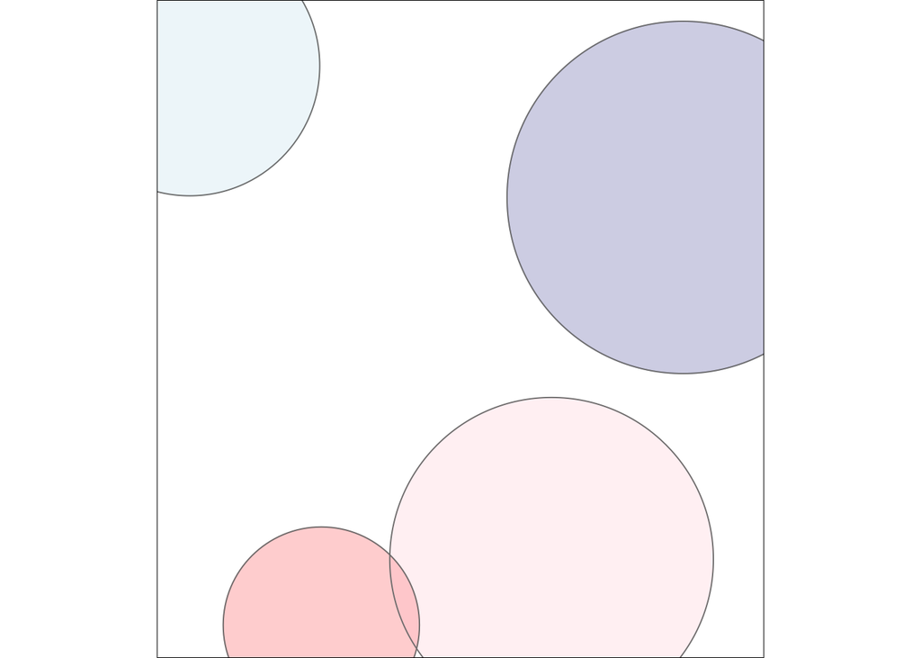

```r
circles %>%
  ggplot(aes(x = x, y = y, color = color, size = size)) +
  geom_point(shape = 19, alpha = 0.2) +
  geom_point(shape = 1, color = "gray50") +
  scale_size(range = c(50, 90)) +
  scale_color_manual(values = circle_colors) +
  coord_equal(xlim = xlim, ylim = ylim, expand = F) +
  theme_void() +
  theme(legend.position = "none", panel.border = element_rect(fill = NA))
```

## Make many designs

Now I just run a loop and write out pdfs with `ggsave`. I do this because I can now print this with tiling from Adobe Reader or I could send it to a printer with larger poster printing.

Note that I write these out at 1x scale. So I need to change the `scale_size` range. Again, I just manually set these to something I liked with some trial and error.

```r
for (b in 1:5) {
  circles <- data.frame(
    x = sample(c(0.5:3, 6:(xlim[2]-0.5)), 4),
    y = sample(c(0.5:3, 7:9.5), 4),
    size = size_dist,
    color = c("a", "b", "c", "d")
  )

  circles %>%
    ggplot(aes(x = x, y = y, color = color, size = size)) +
    geom_point(shape = 19, alpha = 0.2) +
    geom_point(shape = 1, color = "gray50") +
    scale_size(range = c(50*10, 90*10)) +
    scale_color_manual(values = c("a" = "red",
                                  "b" = "lightblue",
                                  "c" = "pink",
                                  "d" = "navy")) +
    coord_equal(xlim = xlim, ylim = ylim, expand = F) +
    theme_void() +
    theme(legend.position = "none", panel.border = element_rect(fill = NA))

  # when you print - make a pdf these dimensions
  ggsave(paste0("~/Downloads/quilt_circles/circles_",b,".pdf"),
         width = final_size[1], height = final_size[2])
}
```

## Can we calculate the fabric needed?

One challenge for a big quilt like this is knowing how much fabric to buy.

In some other code in this repo, I calculated areas for polygons and then used that. Here I need to try to get the areas of the points from the ggplot2 object.

`ggplot_build()` is a useful function! I can return the “size” for each point (before they are clipped by the side of the plot).

```r
plot_obj <- circles %>%
  ggplot(aes(x = x, y = y, color = color, size = size)) +
  geom_point(shape = 19, alpha = 0.2) +
  geom_point(shape = 1, color = "gray50") +
  scale_size(range = c(50, 90)) +
  scale_color_manual(values = circle_colors) +
  coord_equal(xlim = xlim, ylim = ylim, expand = F) +
  theme_void() +
  theme(legend.position = "none", panel.border = element_rect(fill = NA))

ggplot_build(plot_obj)$data[[1]]
```

```
##       size    colour   x   y PANEL group shape fill alpha stroke
## 1 50.00000       red 2.5 0.5     1     1    19   NA   0.2    0.5
## 2 66.32993 lightblue 0.5 9.0     1     2    19   NA   0.2    0.5
## 3 82.65986      pink 6.0 1.5     1     3    19   NA   0.2    0.5
## 4 90.00000      navy 8.0 7.0     1     4    19   NA   0.2    0.5
```

Now I need to adjust for the part of the circle that is cropped, calculate the area of each intersection, and add extra for the seams.

But first, I need to understand the units. For “size” here, we scaled the area. But the units are hard to convert to inches. Are they points? See the [documentation](https://ggplot2.tidyverse.org/reference/scale_size.html).

I created a conversion factor by writing a file with known sizes and measuring. My measurements found that actually, the size was the diameter * 33.33.

- size 50 = 1.767 in^2 (1.5 in diameter)
- size 100 = 7.07 in^2 (3 in diameter)
- size 500 = 176.7 in^2
- size 900 = 572.6 in^2

```r
data.frame(
    x = 0.5,
    y = 0.5,
    size = 5,
    color = "a"
  ) %>%
  ggplot(aes(x = x, y = y, color = color, size = size)) +
  geom_point(shape = 19, alpha = 0.2) +
  geom_point(shape = 1, color = "gray50") +
  scale_size(range = c(100, 100)) +
  scale_color_manual(values = circle_colors) +
  coord_equal(xlim = c(0, 1), ylim = c(0, 1), expand = F) +
  theme_void() +
  theme(legend.position = "none", panel.border = element_rect(fill = NA))
ggsave("~/Downloads/test_4.pdf", width = 4, height = 4)
```

Now, I will just use a conservative estimate for the four main fabrics.

- Let’s assume that there are 2 size 900 circles and 2 size 500 circles. That would be about 1500 in^2.
- If we assume a fabric bolt has 42 inches of usable width, then that is 35.7 inches or about 1 yard.
- For the 6 secondary color fabrics, I will just assume a half-yard is enough.

Finally, for the background fabric, I need 3735 in^2 total. We can round this up to 3.5 yards.

- 6 in wide x 88 in long for the three verticals
- 6 in wide x 88 in long for two (top/bottom) horizontals
- 6 in wide x 82.5 in long for center horizontal
- some amount for the 4 blocks with circles (estimate 600 in^2)

To restate these estimates:

- 3.5 yds background
- 1 yd each of 4 main fabrics
- 0.5 yd each of 6 secondary fabrics

This comes to a total of 10.5 yds. A quick Google search suggested that 8 yds is typical, so I think this is probably not a terrible estimate.

## Can we pick colors?

Here we need a decent number of colors. Honestly, I plan to use fewer unique colors by using the same colors multiple times.

How many colors? 14 unique colors.

- 4 colors for the main circles
- 6 (4 choose 2) for the intersections of two circles
- 4 (4 choose 3) for the intersections of three circles
- I will avoid cases when all four circles intersect

Using R to match the colors to fabric colors might be challenging. The data above has the colors (which I could use hex instead) for each point, but not for the intersections. I could extract the colors from the exported pdf using Illustrator or other tools.

I think this will actually be much better to improv a bit based on what looks good in real light when making the quilt.